# SAVI case study — universal healthy baseline

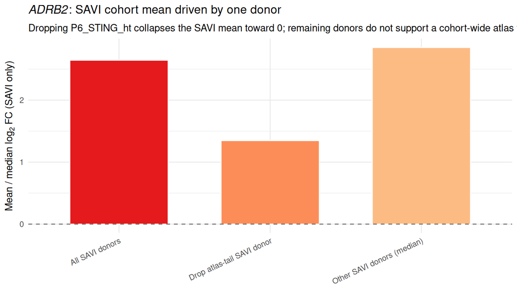

```r
adrb2_loo_plot <- adrb2_loo_summary |>
  dplyr::mutate(
    contrast = factor(
      .data$contrast,
      levels = .data$contrast
    )
  )

ggplot2::ggplot(
  adrb2_loo_plot,
  ggplot2::aes(x = contrast, y = mean_log2fc, fill = contrast)
) +
  ggplot2::geom_col(width = 0.65, colour = "white") +
  ggplot2::geom_hline(yintercept = 0, linetype = 2, colour = "grey45") +
  ggplot2::scale_fill_manual(values = c("#E41A1C", "#FC8D59", "#FDBB84"), guide = "none") +
  ggplot2::labs(
    x = NULL,
    y = expression("Mean / median " * log[2] * " FC (SAVI only)"),
    title = expression(italic("ADRB2") * ": SAVI cohort mean driven by one donor"),
    subtitle = paste0(
      "Dropping ",
      adrb2_savi_outlier$Sample,
      " collapses the SAVI mean toward 0; remaining donors do not support a cohort-wide atlas tail."
    )
  ) +
  ggplot2::theme_minimal(base_size = 11) +
  ggplot2::theme(axis.text.x = ggplot2::element_text(angle = 25, hjust = 1))
```

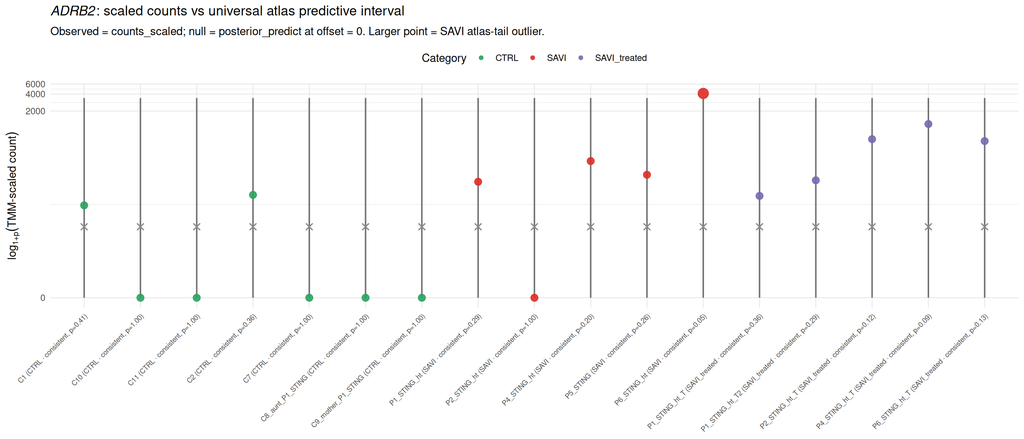

```r
log1p_trans <- scales::trans_new(
  name = "log1p",
  transform = function(x) log1p(pmax(x, 0)),
  inverse = function(x) expm1(x),
  domain = c(0, Inf)
)

adrb2_hpd_plot <- adrb2_sample_tbl |>
  dplyr::transmute(
    sample_label,
    Category,
    savi_outlier,
    hpd_lo = .data$healthy_hpd_lo,
    hpd_hi = .data$healthy_hpd_hi,
    pred_median = .data$healthy_median,
    abundance = .data$observed_scaled
  )

ggplot2::ggplot(adrb2_hpd_plot) +
  ggplot2::geom_linerange(
    ggplot2::aes(
      x = sample_label,
      ymin = hpd_lo,
      ymax = hpd_hi
    ),
    colour = "grey45",
    linewidth = 0.7
  ) +
  ggplot2::geom_point(
    ggplot2::aes(x = sample_label, y = pred_median),
    shape = 4,
    size = 2.2,
    colour = "grey55",
    stroke = 0.9
  ) +
  ggplot2::geom_point(
    ggplot2::aes(
      x = sample_label,
      y = abundance,
      colour = Category,
      size = savi_outlier
    ),
    alpha = 0.9
  ) +
  ggplot2::scale_y_continuous(trans = log1p_trans) +
  ggplot2::scale_colour_manual(values = category_cols) +
  ggplot2::scale_size_manual(values = c(`TRUE` = 4.5, `FALSE` = 3), guide = "none") +
  ggplot2::labs(
    x = NULL,
    y = expression(log[1 + p]("TMM-scaled count")),
    title = expression(italic("ADRB2") * ": scaled counts vs universal atlas predictive interval"),
    subtitle = paste(
      "Observed = counts_scaled; null = posterior_predict at offset = 0.",
      "Larger point = SAVI atlas-tail outlier."
    )
  ) +
  ggplot2::theme_minimal(base_size = 11) +
  ggplot2::theme(
    axis.text.x = ggplot2::element_text(angle = 45, hjust = 1, size = 7),
    legend.position = "top",
    strip.text = ggplot2::element_text(size = 9)
  )
```

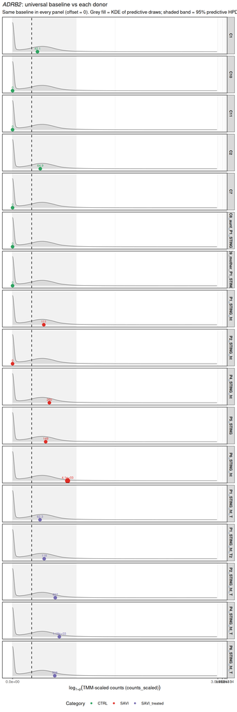

```r
adrb2_baseline_draws_vec <- get_baseline_y_rep_for_gene("ADRB2")

if (is.null(adrb2_baseline_draws_vec)) {
  stop(
    "ADRB2 baseline draws not found. Run `predict-sting-vs-healthy` first ",
    "(or load ", params$gene_baseline_draws_rds, ")."
  )
}

adrb2_baseline_draws_df <- tibble::tibble(
  counts_scaled = adrb2_baseline_draws_vec[is.finite(adrb2_baseline_draws_vec)]
)

adrb2_null_ref <- tibble::tibble(
  median = stats::median(adrb2_baseline_draws_vec, na.rm = TRUE),
  hpd_lo = stats::quantile(adrb2_baseline_draws_vec, 0.025, names = FALSE),
  hpd_hi = stats::quantile(adrb2_baseline_draws_vec, 0.975, names = FALSE)
)

adrb2_patient_panel <- adrb2_sample_tbl |>
  dplyr::arrange(.data$Category, .data$Sample) |>
  dplyr::mutate(
    sample_label = factor(
      .data$Sample,
      levels = unique(.data$Sample)
    ),
    obs_label = sprintf("%.3g", .data$observed_scaled)
  )

ggplot2::ggplot() +
  ggplot2::geom_density(
    data = adrb2_baseline_draws_df,
    ggplot2::aes(x = .data$counts_scaled),
    fill = "grey82",
    colour = "grey35",
    alpha = 0.55,
    linewidth = 0.35,
    na.rm = TRUE,
    inherit.aes = FALSE
  ) +
  ggplot2::geom_rect(
    data = adrb2_null_ref,
    ggplot2::aes(
      xmin = .data$hpd_lo,
      xmax = .data$hpd_hi,
      ymin = -Inf,
      ymax = Inf
    ),
    fill = "grey55",
    alpha = 0.12,
    inherit.aes = FALSE
  ) +
  ggplot2::geom_vline(
    data = adrb2_null_ref,
    ggplot2::aes(xintercept = .data$median),
    linetype = "dashed",
    colour = "grey15",
    linewidth = 0.6,
    inherit.aes = FALSE
  ) +
  ggplot2::geom_point(
    data = adrb2_patient_panel,
    ggplot2::aes(
      x = .data$observed_scaled,
      y = 0,
      colour = .data$Category,
      size = .data$savi_outlier
    ),
    stroke = 0.4
  ) +
  ggplot2::geom_text(
    data = adrb2_patient_panel,
    ggplot2::aes(
      x = .data$observed_scaled,
      y = 0,
      label = .data$obs_label,
      colour = .data$Category
    ),
    size = 2.4,
    vjust = -0.8,
    show.legend = FALSE
  ) +
  ggplot2::facet_grid(
    rows = ggplot2::vars(sample_label),
    labeller = ggplot2::label_wrap_gen(14)
  ) +
  ggplot2::scale_x_continuous(trans = "log1p") +
  ggplot2::scale_y_continuous(
    breaks = NULL,
    labels = NULL,
    expand = ggplot2::expansion(mult = c(0.08, 0.18))
  ) +
  ggplot2::scale_colour_manual(values = category_cols, name = "Category") +
  ggplot2::scale_size_manual(values = c(`TRUE` = 4.5, `FALSE` = 3), guide = "none") +
  ggplot2::coord_cartesian(ylim = c(0, NA), clip = "off") +
  ggplot2::labs(
    x = expression(log[1 + p]("TMM-scaled counts (counts_scaled)")),
    y = NULL,
    title = expression(italic("ADRB2") * ": universal baseline vs each donor"),
    subtitle = paste(
      "Same baseline in every panel (offset = 0).",
      "Grey fill = KDE of predictive draws;",
      "shaded band = 95% predictive HPD; dashed = median;",
      "larger point = SAVI atlas-tail outlier."
    )
  ) +
  ggplot2::theme_bw(base_size = 10) +
  ggplot2::theme(
    legend.position = "bottom",
    strip.text = ggplot2::element_text(size = 8, face = "bold"),
    panel.spacing = grid::unit(0.3, "lines")
  )
```

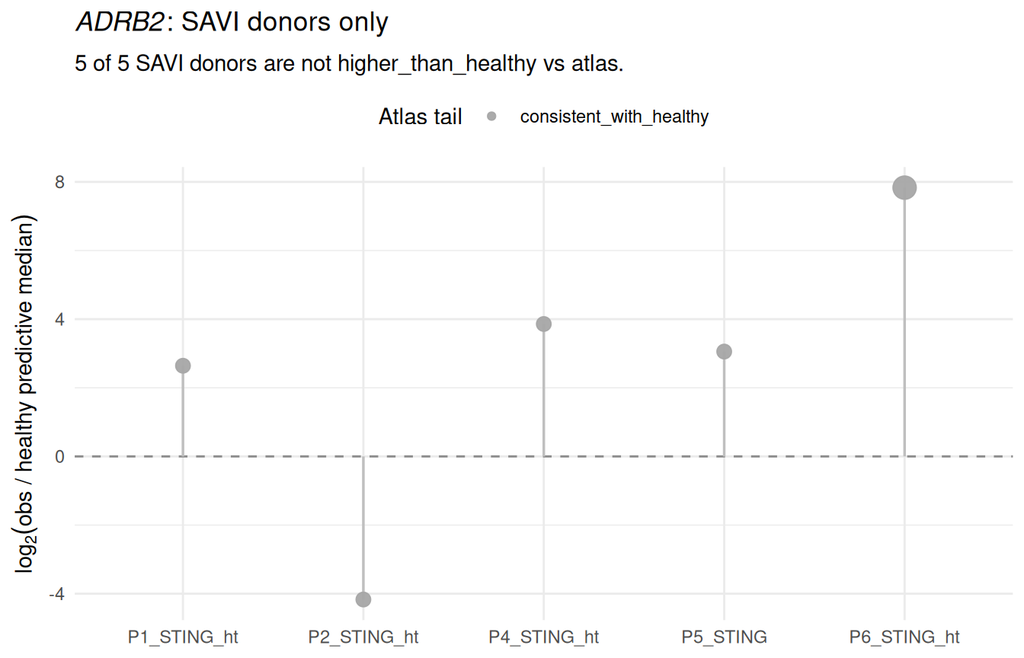

```r
ggplot2::ggplot(
  adrb2_savi_tbl |>
    dplyr::mutate(
      highlight = .data$sample %in% adrb2_savi_outlier$sample,
      Sample = factor(.data$Sample, levels = adrb2_savi_tbl$Sample)
    ),
  ggplot2::aes(x = Sample, y = log2fc_vs_median, colour = direction)
) +
  ggplot2::geom_hline(yintercept = 0, linetype = 2, colour = "grey55") +
  ggplot2::geom_segment(
    ggplot2::aes(x = Sample, xend = Sample, y = 0, yend = log2fc_vs_median),
    colour = "grey75",
    linewidth = 0.6
  ) +
  ggplot2::geom_point(
    ggplot2::aes(size = highlight),
    alpha = 0.95
  ) +
  ggplot2::scale_colour_manual(values = direction_cols, name = "Atlas tail") +
  ggplot2::scale_size_manual(values = c(`TRUE` = 5, `FALSE` = 3), guide = "none") +
  ggplot2::labs(
    x = NULL,
    y = expression(log[2]("obs / healthy predictive median")),
    title = expression(italic("ADRB2") * ": SAVI donors only"),
    subtitle = paste0(
      nrow(adrb2_savi_tbl) - sum(adrb2_savi_tbl$direction == "higher_than_healthy"),
      " of ",
      nrow(adrb2_savi_tbl),
      " SAVI donors are not higher_than_healthy vs atlas."
    )
  ) +
  ggplot2::theme_minimal(base_size = 11) +
  ggplot2::theme(legend.position = "top")
```

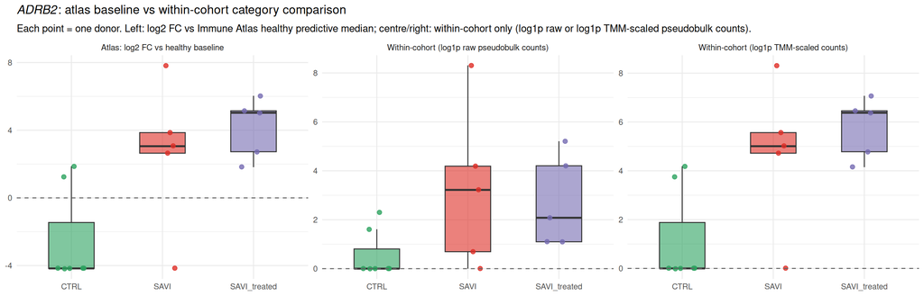

```r
adrb2_two_nulls_long <- dplyr::bind_rows(
  adrb2_sample_tbl |>
    dplyr::mutate(
      metric = "Atlas: log2 FC vs healthy baseline",
      value = .data$log2fc_vs_median
    ),
  adrb2_sample_tbl |>
    dplyr::mutate(
      metric = "Within-cohort (log1p raw pseudobulk counts)",
      value = log1p(.data$observed_count)
    ),
  adrb2_sample_tbl |>
    dplyr::mutate(
      metric = "Within-cohort (log1p TMM-scaled counts)",
      value = log1p(pmax(.data$observed_scaled, 0))
    )
) |>
  dplyr::mutate(
    Category = factor(.data$Category, levels = names(category_cols)),
    metric = factor(
      .data$metric,
      levels = c(
        "Atlas: log2 FC vs healthy baseline",
        "Within-cohort (log1p raw pseudobulk counts)",
        "Within-cohort (log1p TMM-scaled counts)"
      )
    )
  )

ggplot2::ggplot(
  adrb2_two_nulls_long,
  ggplot2::aes(x = .data$Category, y = .data$value, fill = .data$Category)
) +
  ggplot2::geom_boxplot(width = 0.5, outlier.shape = NA, alpha = 0.6) +
  ggplot2::geom_jitter(
    ggplot2::aes(colour = .data$Category),
    width = 0.15,
    size = 2,
    alpha = 0.8,
    show.legend = FALSE
  ) +
  ggplot2::geom_hline(yintercept = 0, linetype = 2, colour = "grey40") +
  ggplot2::facet_wrap(~metric, scales = "free_y", ncol = 3) +
  ggplot2::scale_fill_manual(values = category_cols) +
  ggplot2::scale_colour_manual(values = category_cols) +
  ggplot2::labs(
    x = NULL,
    y = NULL,
    title = expression(italic("ADRB2") * ": atlas baseline vs within-cohort category comparison"),
    subtitle = paste0(
      "Each point = one donor. ",
      "Left: log2 FC vs Immune Atlas healthy predictive median; ",
      "centre/right: within-cohort only (log1p raw or log1p TMM-scaled pseudobulk counts)."
    )
  ) +
  ggplot2::theme_minimal(base_size = 11) +
  ggplot2::theme(
    legend.position = "none",
    strip.text = ggplot2::element_text(size = 9)
  )
```

```r
# Baseline draws from `falsify-predictive-draws` (one 400-draw vector per gene).
if (!exists("contrast_baseline_draws", inherits = TRUE)) {
  stop("Run chunk `falsify-predictive-draws` first.")
}

if (!"ADRB2" %in% as.character(contrast_baseline_draws$gene)) {
  stop(
    "ADRB2 not in `contrast_baseline_draws`. Re-run `falsify-predictive-draws` ",
    "(clear knitr cache if the chunk was run before ADRB2 was added)."
  )
}

# Observed lines from `gene_deviation_eval` (robust if predictive-draws cache is stale).
adrb2_sample_obs <- dplyr::bind_rows(
  case_study_obs_from_deviation(
    "ADRB2",
    outlier_samples = adrb2_savi_outlier$sample
  ),
  case_study_obs_from_deviation("TSC22D2")
) |>
  dplyr::left_join(
    adrb2_sample_tbl |>
      dplyr::select("sample", "sample_label"),
    by = "sample"
  )

list(
  n_baseline_draws = contrast_baseline_draws |>
    dplyr::filter(.data$gene %in% adrb2_contrast_genes) |>
    dplyr::count(.data$gene, name = "n_draws"),
  n_samples = adrb2_sample_obs |>
    dplyr::count(.data$gene, .data$Category, name = "n_samples")
)
```

```
$n_baseline_draws
# A tibble: 2 × 2
  gene    n_draws
  <fct>     <int>
1 TSC22D2     400
2 ADRB2       400

$n_samples
# A tibble: 6 × 3
  gene    Category     n_samples
  <chr>   <fct>            <int>
1 ADRB2   CTRL                 7
2 ADRB2   SAVI                 5
3 ADRB2   SAVI_treated         5
4 TSC22D2 CTRL                 7
5 TSC22D2 SAVI                 5
6 TSC22D2 SAVI_treated         5
```

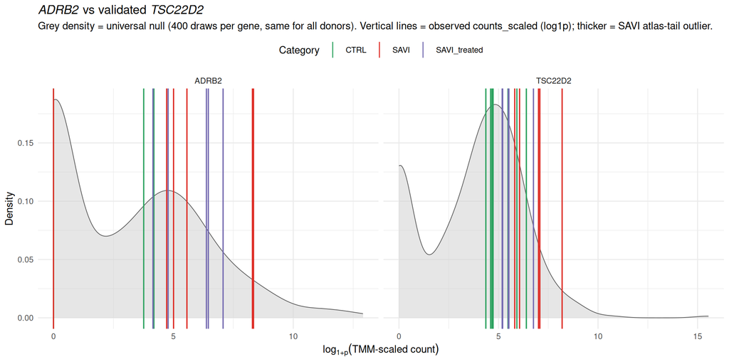

```r
ggplot2::ggplot() +
  ggplot2::geom_density(
    data = contrast_baseline_draws |>
      dplyr::filter(.data$gene %in% adrb2_contrast_genes),
    ggplot2::aes(x = .data$draw_log1p),
    fill = "grey82",
    colour = "grey35",
    alpha = 0.55,
    linewidth = 0.35,
    inherit.aes = FALSE
  ) +
  ggplot2::geom_vline(
    data = adrb2_sample_obs,
    ggplot2::aes(
      xintercept = .data$observed_log1p,
      colour = .data$Category,
      linewidth = dplyr::if_else(.data$gene == "ADRB2", .data$savi_outlier, FALSE)
    ),
    linetype = "solid"
  ) +
  ggplot2::scale_linewidth_manual(values = c(`TRUE` = 1.2, `FALSE` = 0.65), guide = "none") +
  ggplot2::facet_wrap(~gene, scales = "free_x") +
  ggplot2::scale_colour_manual(values = category_cols, name = "Category") +
  ggplot2::labs(
    x = expression(log[1 + p]("TMM-scaled count")),
    y = "Density",
    title = expression(italic("ADRB2") * " vs validated " * italic("TSC22D2")),
    subtitle = paste(
      "Grey density = universal null (400 draws per gene, same for all donors).",
      "Vertical lines = observed counts_scaled (log1p); thicker = SAVI atlas-tail outlier."
    )
  ) +
  ggplot2::theme_minimal(base_size = 11) +
  ggplot2::theme(legend.position = "top")
```

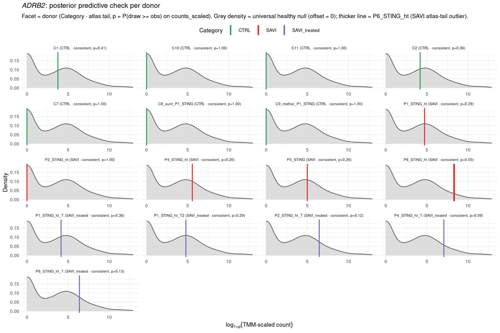

```r
if (!exists("contrast_baseline_draws", inherits = TRUE)) {
  stop("Run chunk `falsify-predictive-draws` first.")
}

if (!exists("adrb2_sample_obs", inherits = TRUE)) {
  stop("Run chunk `adrb2-predictive-draws-check` first.")
}

adrb2_baseline_draws_plot <- contrast_baseline_draws |>
  dplyr::filter(.data$gene == "ADRB2")

adrb2_sample_obs_plot <- case_study_obs_from_deviation(
  "ADRB2",
  outlier_samples = adrb2_savi_outlier$sample
) |>
  dplyr::left_join(
    adrb2_sample_tbl |>
      dplyr::select("sample", "sample_label"),
    by = "sample"
  )

if (nrow(adrb2_sample_obs_plot) == 0L || all(is.na(adrb2_sample_obs_plot$sample_label))) {
  stop("`adrb2_sample_tbl` has no ADRB2 rows with facet labels.")
}

ggplot2::ggplot() +
  ggplot2::geom_density(
    data = adrb2_baseline_draws_plot,
    ggplot2::aes(x = .data$draw_log1p),
    fill = "grey85",
    colour = "grey40",
    linewidth = 0.6,
    alpha = 0.9,
    inherit.aes = FALSE
  ) +
  ggplot2::geom_vline(
    data = adrb2_sample_obs_plot,
    ggplot2::aes(
      xintercept = .data$observed_log1p,
      colour = .data$Category,
      linewidth = .data$savi_outlier
    ),
    linetype = "solid"
  ) +
  ggplot2::scale_linewidth_manual(values = c(`TRUE` = 1.3, `FALSE` = 0.8), guide = "none") +
  ggplot2::facet_wrap(~sample_label, scales = "free_x", ncol = 4) +
  ggplot2::scale_colour_manual(values = category_cols, name = "Category") +
  ggplot2::guides(colour = ggplot2::guide_legend(override.aes = list(linewidth = 1.2))) +
  ggplot2::labs(
    x = expression(log[1 + p]("TMM-scaled count")),
    y = "Density",
    title = expression(italic("ADRB2") * ": posterior predictive check per donor"),
    subtitle = paste(
      "Facet = donor (Category · atlas tail, p = P(draw >= obs) on counts_scaled).",
      "Grey density = universal healthy null (offset = 0); thicker line =",
      adrb2_savi_outlier$Sample,
      "(SAVI atlas-tail outlier)."
    )
  ) +
  ggplot2::theme_minimal(base_size = 10) +
  ggplot2::theme(
    legend.position = "top",
    strip.text = ggplot2::element_text(size = 6.5)
  )
```

```r
adrb2_biomarker_row <- biomarker_quality |>
  dplyr::filter(.data$gene == "ADRB2")

tibble::tibble(
  gene = "ADRB2",
  biomarker_class = adrb2_biomarker_row$biomarker_class,
  pct_higher_SAVI = adrb2_biomarker_row$pct_higher.SAVI,
  mean_log2fc_SAVI = adrb2_biomarker_row$savi_lift,
  savi_vs_ctrl_atlas = adrb2_biomarker_row$savi_vs_ctrl,
  outlier_sample = adrb2_savi_outlier$Sample,
  outlier_log2fc = adrb2_savi_outlier$log2fc_vs_median,
  n_savi_higher = sum(adrb2_savi_tbl$direction == "higher_than_healthy"),
  n_savi_consistent = sum(adrb2_savi_tbl$direction == "consistent_with_healthy"),
  mean_log2fc_SAVI_drop_outlier = adrb2_loo_summary$mean_log2fc[2],
  falsification_verdict = paste(
    "Cohort SAVI mean is not a robust signature signal:",
    "only",
    sum(adrb2_savi_tbl$direction == "higher_than_healthy"),
    "of",
    nrow(adrb2_savi_tbl),
    "SAVI donors exceed the atlas null;",
    "effect driven by",
    adrb2_savi_outlier$Sample
  )
)
```

| gene | biomarker_class | pct_higher_SAVI | mean_log2fc_SAVI | savi_vs_ctrl_atlas | outlier_sample | outlier_log2fc | n_savi_higher | n_savi_consistent | mean_log2fc_SAVI_drop_outlier | falsification_verdict |
| --- | --- | --- | --- | --- | --- | --- | --- | --- | --- | --- |
| ADRB2 | falsified_no_savi_signal | 0 | 2.64412 | 5.175268 | P6_STING_ht | 7.832823 | 0 | 5 | 1.346944 | Cohort SAVI mean is not a robust signature signal: only 0 of 5 SAVI donors exceed the atlas null; effect driven by P6_STING_ht |

# Single-cell expression on UMAP (GEO Seurat object)

Published scRNA-seq object GSE226598 (`prepare_data.R`). We subset **`params$savi_sc_celltype`** (disease-associated monocytes — same population as the pseudobulk merge) and plot signature genes on the embedded UMAP, **`split.by = "Category"`** (`CTRL`, `SAVI`, `SAVI_treated`), using the **`SCT`** assay **`data`** slot (SCTransform–normalized expression from the published object).

```r
read_geo_rds_gz <- function(path) {
  con <- gzcon(gzfile(path))
  on.exit(close(con), add = TRUE)
  readRDS(con)
}

seurat_savi <- read_geo_rds_gz(params$savi_seurat_gz)

if (!"Category" %in% colnames(seurat_savi@meta.data)) {
  stop("`Category` not found in Seurat metadata.")
}

seurat_savi$Category <- factor(
  seurat_savi$Category,
  levels = c("CTRL", "SAVI", "SAVI_treated")
)

seurat_reduction <- function(se) {
  nms <- names(se@reductions)
  hit <- intersect(c("umap", "UMAP", "tsne", "TSNE"), nms)
  if (length(hit)) {
    return(hit[[1]])
  }
  nms[[1]]
}

reduction_use <- seurat_reduction(seurat_savi)

# Subset early so we don't keep the full >2k x 24k object around.
seurat_savi_mono <- seurat_savi |>
  subset(CellType == params$savi_sc_celltype)
# rm(seurat_savi)
# gc(verbose = FALSE)

tibble::tibble(
  n_cells = ncol(seurat_savi_mono),
  reduction = reduction_use,
  categories = paste(levels(seurat_savi_mono$Category), collapse = ", "),
  il1b_present = "IL1B" %in% rownames(seurat_savi_mono),
  adrb2_present = "ADRB2" %in% rownames(seurat_savi_mono)
)
```

| n_cells | reduction | categories | il1b_present | adrb2_present |
| --- | --- | --- | --- | --- |
| 2290 | umap | CTRL, SAVI, SAVI_treated | TRUE | TRUE |

```r
if (ncol(seurat_savi_mono) == 0L) {
  stop(
    "No cells for CellType = '", params$savi_sc_celltype,
    "'. Check `CellType` levels in the Seurat object."
  )
}

seurat_savi_mono$Category <- factor(
  seurat_savi_mono$Category,
  levels = c("CTRL", "SAVI", "SAVI_treated")
)

tibble::tibble(
  cell_type = params$savi_sc_celltype,
  n_cells = ncol(seurat_savi_mono)
)
```

| cell_type | n_cells |
| --- | --- |
| 17. Disease-associated monocytes | 2290 |

```r
table(seurat_savi_mono$Category, useNA = "ifany")
```

```
        CTRL         SAVI SAVI_treated
         344         1528          418
```

#### *IL1B* on UMAP (all donors, paper scaled)

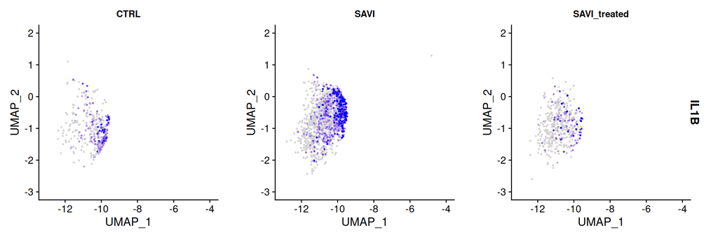

```r
if (!"SCT" %in% SeuratObject::Assays(seurat_savi_mono)) {
  stop(
    "SCT assay not found. Available: ",
    paste(SeuratObject::Assays(seurat_savi_mono), collapse = ", ")
  )
}

if (!"IL1B" %in% rownames(seurat_savi_mono[["SCT"]])) {
  stop("IL1B not found in SCT assay rownames.")
}

Seurat::FeaturePlot(
  seurat_savi_mono,
  features = "IL1B",
  assay = "SCT",
  split.by = "Category",
  reduction = reduction_use,
  slot = "data",
  ncol = 3,
  order = TRUE,
  pt.size = 0.35,
  min.cutoff = "q10",
  max.cutoff = "q90"
) &
  ggplot2::theme(
    plot.title = ggplot2::element_text(size = 11),
    strip.text = ggplot2::element_text(size = 11, face = "bold")
  )
```

#### *IL1B* on UMAP (all donors, TMMwsp scaled)

Same **`split.by = "Category"`** layout as above, but scaling is **TMMwsp on single-cell raw counts** (not pseudobulk multipliers). We run `edgeR::calcNormFactors(..., method = "TMMwsp")` on the **per-cell library sizes** from the `RNA` `counts` slot, derive a per-cell scaling factor, and store the result in a new **`TMMwsp`** assay for `FeaturePlot`.

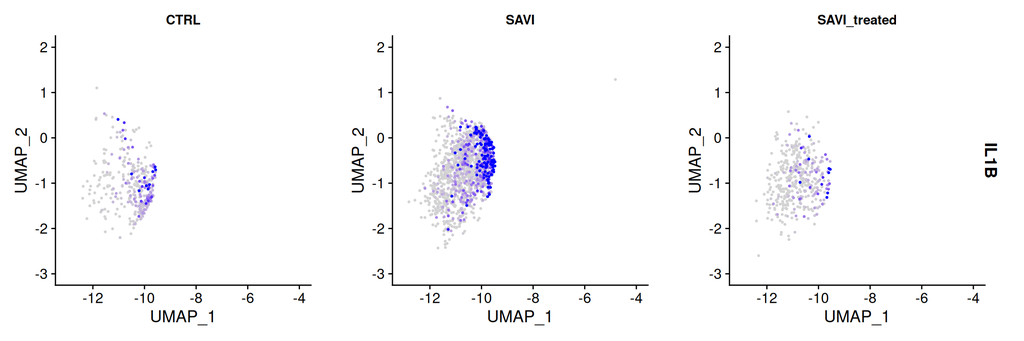

```r
if (!"RNA" %in% SeuratObject::Assays(seurat_savi_mono)) {
  stop(
    "RNA assay not found. Available: ",
    paste(SeuratObject::Assays(seurat_savi_mono), collapse = ", ")
  )
}

if (!"IL1B" %in% rownames(seurat_savi_mono[["RNA"]])) {
  stop("IL1B not found in RNA assay rownames.")
}

rna_counts <- Seurat::GetAssayData(seurat_savi_mono, assay = "RNA", layer = "counts")

lib_size <- Matrix::colSums(rna_counts)

dge <- edgeR::DGEList(counts = rna_counts, lib.size = lib_size)
dge <- edgeR::calcNormFactors(dge, method = "TMMwsp")

eff_lib <- dge$samples$lib.size * dge$samples$norm.factors
scale_factor <- median(eff_lib) / eff_lib

tmmwsp_data <- Matrix::t(Matrix::t(rna_counts) * scale_factor)

seurat_savi_mono[["TMMwsp"]] <- Seurat::CreateAssayObject(data = tmmwsp_data)

Seurat::FeaturePlot(
  seurat_savi_mono,
  features = "IL1B",
  assay = "TMMwsp",
  split.by = "Category",
  reduction = reduction_use,
  slot = "data",
  ncol = 3,
  order = TRUE,
  pt.size = 0.35,
  min.cutoff = "q10",
  max.cutoff = "q90"
) &
  ggplot2::theme(
    plot.title = ggplot2::element_text(size = 11),
    strip.text = ggplot2::element_text(size = 11, face = "bold")
  )
```

The panel above uses **all** disease-associated monocytes per **`Category`** (cell counts differ across arms). Below we **downsample to a balanced number of cells per `Category`** (random sample of size `min_n` within each arm, `set.seed(42)`) so UMAP colour density is not driven by unequal *n*.

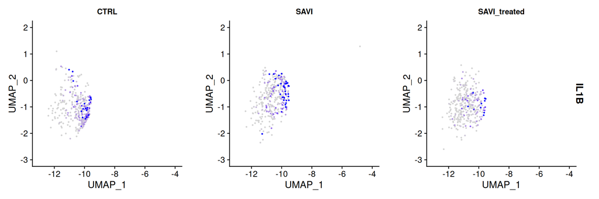

```r
set.seed(42L)
cells_per_cat <- split(
  colnames(seurat_savi_mono),
  seurat_savi_mono$Category
)
min_n <- min(vapply(cells_per_cat, length, integer(1)))
balanced_cells <- unlist(
  lapply(cells_per_cat, function(cc) sample(cc, min_n)),
  use.names = FALSE
)
seurat_balanced <- subset(seurat_savi_mono, cells = balanced_cells)

Seurat::FeaturePlot(
  seurat_balanced,
  features = "IL1B",
  assay = "TMMwsp",
  split.by = "Category",
  reduction = reduction_use,
  slot = "data",
  ncol = 3,
  order = TRUE,
  pt.size = 0.35,
  min.cutoff = "q10",
  max.cutoff = "q90"
) &
  ggplot2::theme(
    plot.title = ggplot2::element_text(size = 11),
    strip.text = ggplot2::element_text(size = 11, face = "bold")
  )
```

Panel titles are **`Category`**. The **paper-scaled** panel above uses **SCT**; these two panels use **TMMwsp** on single-cell `RNA` counts (`edgeR::calcNormFactors`), first with all cells then with balanced *n* per arm.

#### *ADRB2* on UMAP (all donors)

Same layout as *IL1B*: disease-associated monocytes, SCT **`data`**, **`split.by = "Category"`**. Compare the **SAVI** column to **CTRL** and **SAVI_treated** — cells from all donors in each arm are pooled on the UMAP.

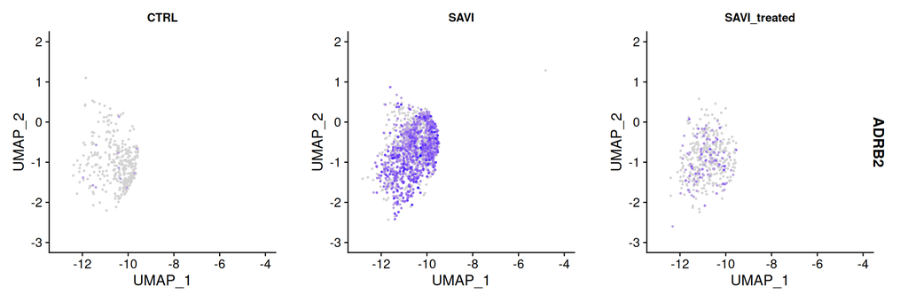

```r
if (!"ADRB2" %in% rownames(seurat_savi_mono[["SCT"]])) {
  stop("ADRB2 not found in SCT assay rownames.")
}

Seurat::FeaturePlot(
  seurat_savi_mono,
  features = "ADRB2",
  assay = "SCT",
  split.by = "Category",
  reduction = reduction_use,
  slot = "data",
  ncol = 3,
  order = TRUE,
  pt.size = 0.35,
  # min.cutoff = "q10",
  # max.cutoff = "q90"
) &
  ggplot2::theme(
    plot.title = ggplot2::element_text(size = 11),
    strip.text = ggplot2::element_text(size = 11, face = "bold")
  )
```

#### *ADRB2* after removing the atlas-tail donor

Mirroring **`plot-adrb2-leave-one-out`** on pseudobulk, we repeat the UMAP with **every disease-associated monocyte from the atlas-tail SAVI donor removed** (`adrb2_savi_outlier$Sample`, here **`P6_STING_ht`**). Assay, cell type, and **`split.by = "Category"`** are unchanged; only that library’s cells are dropped, so the **SAVI** facet reflects the remaining four untreated SAVI donors. If the **SAVI** panel now resembles **CTRL** / **SAVI_treated**, the cohort-level **`ADRB2`** signal is a **one-donor** artefact at single-cell resolution as well as in pseudobulk.

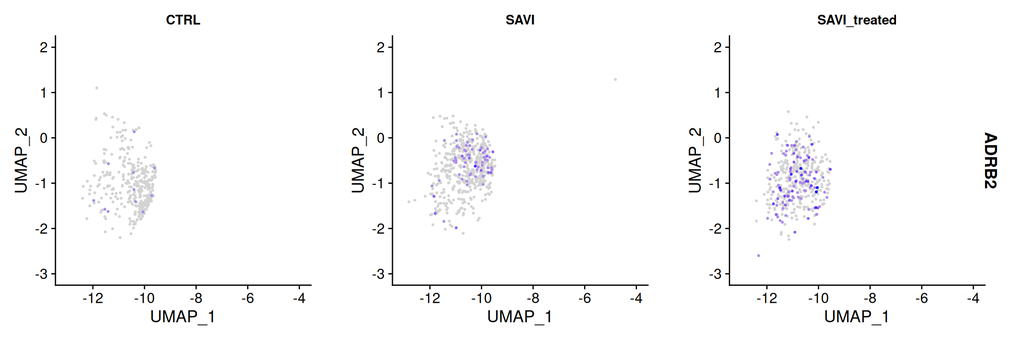

```r
if (!"ADRB2" %in% rownames(seurat_savi_mono[["SCT"]])) {
  stop("ADRB2 not found in SCT assay rownames.")
}

if (!"Sample" %in% colnames(seurat_savi_mono@meta.data)) {
  stop("`Sample` not found in Seurat metadata.")
}

outlier_sample <- adrb2_savi_outlier$Sample

seurat_savi_mono_no_outlier <- subset(
  seurat_savi_mono,
  subset = Sample != outlier_sample
)

Seurat::FeaturePlot(
  seurat_savi_mono_no_outlier,
  features = "ADRB2",
  assay = "SCT",
  split.by = "Category",
  reduction = reduction_use,
  slot = "data",
  ncol = 3,
  order = TRUE,
  pt.size = 0.35,
  # min.cutoff = "q5",
  # max.cutoff = "q95"
) &
  ggplot2::theme(
    plot.title = ggplot2::element_text(size = 11),
    strip.text = ggplot2::element_text(size = 11, face = "bold")
  )
```

# Composition analysis vs original SAVI paper

In the original SAVI scRNA-seq paper (de Cevins *et al.* 2023; GSE226598), after QC, integration, clustering, and annotation, the authors report **23 cell populations** in the SAVI dataset and **29 cell populations** in the IFN-beta dataset. They then compare PBMC composition between SAVI and controls (Figure 1E), with p-values from Kruskal-Wallis tests followed by post hoc Dunn’s multiple-comparison testing.

For whole-PBMC composition, the paper reports increased naive CD4 and naive CD8 T cells, decreased effector/memory CD4 and CD8 T-cell compartments, decreased NK cells (especially NK CD56bright), and strong depletion of MAIT and gamma-delta T cells in SAVI. They also report that cell-type proportions did not differ significantly before versus under JAK-inhibitor treatment.

In this notebook, we use those statements as the reference conclusion, then:

1. compute per-sample proportions from GEO **`CellType`** (23 populations),
2. map **`CellType` → Immune Atlas `L3`** labels used by the sccomp composition model,
3. compare observed proportions to **universal (marginalised)** healthy **`predict_res`** draws (pooled over sex, age decade, and other NA covariates; **`tissue_groups = blood`**, **`disease = Normal`** only),
4. summarise trends in **`CTRL`**, **`SAVI`**, and **`SAVI_treated`** against the paper’s Figure 1E conclusions.

```r
paper_composition_summary <- tibble::tribble(
  ~topic, ~paper_finding,
  "Dataset size after integration", "23 populations (SAVI dataset) and 29 populations (IFN-beta dataset).",
  "Naive T-cell compartments", "Naive CD4 and naive CD8 T-cell proportions are increased in SAVI.",
  "Effector/memory T-cell compartments", "Effector/memory CD4 and CD8 compartments are decreased in SAVI.",
  "Innate-like / cytotoxic compartments", "NK cells (notably NK CD56bright), MAIT cells, and gamma-delta T cells are reduced in SAVI.",
  "Treatment comparison", "No significant composition differences were observed before versus under JAK inhibitor treatment.",
  "Statistics in Figure 1E", "Kruskal-Wallis tests with post hoc Dunn's multiple comparisons."
)

paper_composition_summary
```

| topic | paper_finding |
| --- | --- |
| Dataset size after integration | 23 populations (SAVI dataset) and 29 populations (IFN-beta dataset). |
| Naive T-cell compartments | Naive CD4 and naive CD8 T-cell proportions are increased in SAVI. |
| Effector/memory T-cell compartments | Effector/memory CD4 and CD8 compartments are decreased in SAVI. |
| Innate-like / cytotoxic compartments | NK cells (notably NK CD56bright), MAIT cells, and gamma-delta T cells are reduced in SAVI. |
| Treatment comparison | No significant composition differences were observed before versus under JAK inhibitor treatment. |
| Statistics in Figure 1E | Kruskal-Wallis tests with post hoc Dunn's multiple comparisons. |

```r
paper_ct_alignment <- tibble::tribble(
  ~paper_compartment, ~direction_in_savi, ~celltype_labels_in_this_object, ~mapping_note,
  "Naive CD4 T", "increased", "0. Naive CD4", "Directly aligned.",
  "Effector/memory CD4", "decreased", "3. CM CD4; 4. EM CD4; 8. TE CD4; 9. Tregs and TE CD4", "Approximate effector/memory CD4 pool from available labels.",
  "Naive CD8 T", "increased", "2. Naive CD8", "Directly aligned.",
  "Effector/memory CD8", "decreased", "14. CM CD8; 15. EM CD8; 7. TE CD8", "Approximate effector/memory CD8 pool from available labels.",
  "NK (especially CD56bright)", "decreased", "10. NK; 26. NK CD56bright", "CD56bright is explicitly available.",
  "MAIT", "strongly decreased", "22. MAIT", "Directly aligned.",
  "gamma-delta T", "strongly decreased", "16. gd T cells", "Directly aligned.",
  "Myeloid context (not primary Figure 1E claim)", "context", "5. Classical monocytes; 12. Non-classical monocytes; 17. Disease-associated monocytes; 20. cDCs; 27. pDCs", "Contextual comparison only.",
  "B-cell context (not primary Figure 1E claim)", "context", "1. Naive B; 6. Transitionnal B; 13. Memory B; 11. CD3+ B cells; 25. Plasmablasts", "Contextual comparison only."
)

paper_ct_alignment
```

| paper_compartment | direction_in_savi | celltype_labels_in_this_object | mapping_note |
| --- | --- | --- | --- |
| Naive CD4 T | increased | 0. Naive CD4 | Directly aligned. |
| Effector/memory CD4 | decreased | 3. CM CD4; 4. EM CD4; 8. TE CD4; 9. Tregs and TE CD4 | Approximate effector/memory CD4 pool from available labels. |
| Naive CD8 T | increased | 2. Naive CD8 | Directly aligned. |
| Effector/memory CD8 | decreased | 14. CM CD8; 15. EM CD8; 7. TE CD8 | Approximate effector/memory CD8 pool from available labels. |
| NK (especially CD56bright) | decreased | 10. NK; 26. NK CD56bright | CD56bright is explicitly available. |
| MAIT | strongly decreased | 22. MAIT | Directly aligned. |
| gamma-delta T | strongly decreased | 16. gd T cells | Directly aligned. |
| Myeloid context (not primary Figure 1E claim) | context | 5. Classical monocytes; 12. Non-classical monocytes; 17. Disease-associated monocytes; 20. cDCs; 27. pDCs | Contextual comparison only. |
| B-cell context (not primary Figure 1E claim) | context | 1. Naive B; 6. Transitionnal B; 13. Memory B; 11. CD3+ B cells; 25. Plasmablasts | Contextual comparison only. |

```r
if (!exists("read_geo_rds_gz", mode = "function")) {
  read_geo_rds_gz <- function(path) {
    con <- gzcon(gzfile(path))
    on.exit(close(con), add = TRUE)
    readRDS(con)
  }
}

if (!exists("seurat_savi", inherits = FALSE)) {
  seurat_savi <- read_geo_rds_gz(params$savi_seurat_gz)
}

if (!"Category" %in% colnames(seurat_savi@meta.data)) {
  stop("`Category` not found in Seurat metadata.")
}
if (!"CellType" %in% colnames(seurat_savi@meta.data)) {
  stop("`CellType` not found in Seurat metadata.")
}

seurat_savi$Category <- factor(
  seurat_savi$Category,
  levels = c("CTRL", "SAVI", "SAVI_treated")
)

# GEO sample metadata (same table as pseudobulk join above).
geo_tbl_comp <- geo_tbl |>
  dplyr::mutate(
    sex = dplyr::case_when(
      .data$gse_sex == "M" ~ "male",
      .data$gse_sex == "F" ~ "female",
      TRUE ~ NA_character_
    ),
    age_decade = as.character(ceiling(.data$gse_age_years / 10))
  ) |>
  dplyr::select("Sample", "sex", "age_decade", "gse_age_years")

# Fine-grained CellType -> Immune Atlas L3 (posteriorHCA / sccomp) labels.
celltype_to_l3 <- tibble::tribble(
  ~cell_type, ~L3,
  "0. Naive CD4", "cd4 naive",
  "2. Naive CD8", "cd8 naive",
  "3. CM CD4", "cd4 tcm",
  "4. EM CD4", "cd4 th1 em",
  "8. TE CD4", "cd4 th1 em",
  "9. Tregs and TE CD4", "treg",
  "14. CM CD8", "cd8 tcm",
  "15. EM CD8", "cd8 tem",
  "7. TE CD8", "cd8 tem",
  "10. NK", "nk",
  "26. NK CD56bright", "nk",
  "22. MAIT", "mait",
  "16. gd T cells", "tgd",
  "1. Naive B", "b naive",
  "6. Transitionnal B", "b naive",
  "13. Memory B", "b memory",
  "11. CD3+ B cells", "b memory",
  "5. Classical monocytes", "cd14 mono",
  "12. Non-classical monocytes", "cd16 mono",
  "17. Disease-associated monocytes", "cd14 mono",
  "20. cDCs", "cdc",
  "27. pDCs", "pdc",
  "25. Plasmablasts", "plasma"
)

cell_tbl <- seurat_savi@meta.data |>
  tibble::rownames_to_column("cell_id") |>
  dplyr::transmute(
    sample_id = as.character(.data$Sample),
    Category = as.character(.data$Category),
    cell_type = as.character(.data$CellType)
  ) |>
  dplyr::left_join(celltype_to_l3, by = "cell_type") |>
  dplyr::left_join(geo_tbl_comp, by = c("sample_id" = "Sample"))

example_proportions_celltype <- cell_tbl |>
  dplyr::filter(!is.na(.data$cell_type), nzchar(.data$cell_type)) |>
  dplyr::count(.data$sample_id, .data$cell_type, name = "n_cells") |>
  dplyr::group_by(.data$sample_id) |>
  dplyr::mutate(proportion = .data$n_cells / sum(.data$n_cells)) |>
  dplyr::ungroup() |>
  dplyr::select(.data$sample_id, .data$cell_type, .data$proportion)

# L3-level observed proportions (merge CellType labels that map to the same L3).
example_proportions <- cell_tbl |>
  dplyr::filter(!is.na(.data$L3)) |>
  dplyr::count(.data$sample_id, .data$Category, .data$sex, .data$age_decade, .data$L3, name = "n_cells") |>
  dplyr::group_by(.data$sample_id, .data$Category, .data$sex, .data$age_decade, .data$L3) |>
  dplyr::summarise(proportion = sum(.data$n_cells), .groups = "drop_last") |>
  dplyr::group_by(.data$sample_id) |>
  dplyr::mutate(proportion = .data$proportion / sum(.data$proportion)) |>
  dplyr::ungroup() |>
  dplyr::rename(cell_type = L3) |>
  dplyr::arrange(.data$sample_id, .data$cell_type)

unmapped_celltypes <- cell_tbl |>
  dplyr::filter(is.na(.data$L3)) |>
  dplyr::count(.data$cell_type, sort = TRUE)

tibble::tibble(
  label_column_used = "CellType",
  n_samples = dplyr::n_distinct(example_proportions$sample_id),
  n_cells_total = nrow(cell_tbl),
  n_celltypes_raw = dplyr::n_distinct(example_proportions_celltype$cell_type),
  n_l3_types = dplyr::n_distinct(example_proportions$cell_type),
  n_unmapped_celltypes = nrow(unmapped_celltypes)
)
```

| label_column_used | n_samples | n_cells_total | n_celltypes_raw | n_l3_types | n_unmapped_celltypes |
| --- | --- | --- | --- | --- | --- |
| CellType | 17 | 112060 | 23 | 17 | 0 |

```r
if (nrow(unmapped_celltypes) > 0L) {
  unmapped_celltypes
}
```

### Healthy atlas composition null (`predict_res`)

Posterior draws of blood PBMC composition from the Immune Atlas sccomp model under a **universal** null: **`disease_groups___altered = Normal`**, **`tissue_groups = blood`**, and **`NA`** for **`dataset_id___altered`**, **`sex`**, **`age_decade`**, **`ethnicity_groups_imputed`**, and **`assay_groups___altered`** (sccomp marginalises over those levels). The draw table is saved once to **`params$composition_predict_rds`** (separate RDS from the personalised case study) and trimmed to L3 types present in the SAVI cohort.

```r
if (!requireNamespace("sccomp", quietly = TRUE)) {
  stop("Package `sccomp` is required for composition prediction.")
}

l3_for_comparison <- example_proportions |>
  dplyr::distinct(.data$cell_type) |>
  dplyr::pull(.data$cell_type)

trim_predict_res <- function(x, cell_types) {
  x |>
    dplyr::filter(.data$cell_type %in% cell_types) |>
    dplyr::select(dplyr::any_of(c(
      "sample_id",
      "age_decade",
      "sex",
      "cell_type",
      "proportion",
      ".draw"
    )))
}

if (file.exists(params$composition_predict_rds)) {
  predict_res <- readRDS(params$composition_predict_rds)
} else {
  sccomp_est <- readRDS(params$sccomp_estimates_rds)

  sample_metadata <- tibble::tibble(
    assay_groups___altered = NA_character_,
    disease_groups___altered = "Normal",
    tissue_groups = "blood",
    ethnicity_groups_imputed = NA_character_,
    age_decade = NA_character_,
    sex = NA_character_,
    dataset_id___altered = NA_character_,
    sample_id = "universal_baseline"
  )

  predict_res <- sccomp_est |>
    sccomp::sccomp_predict(
      formula_composition = NULL,
      new_data = sample_metadata,
      summary_instead_of_draws = FALSE
    ) |>
    dplyr::rename(cell_type = L3) |>
    trim_predict_res(l3_for_comparison)

  predict_dir <- dirname(params$composition_predict_rds)
  if (!dir.exists(predict_dir)) {
    dir.create(predict_dir, recursive = TRUE, showWarnings = FALSE)
  }
  saveRDS(predict_res, params$composition_predict_rds, compress = "xz")
}

predict_res <- trim_predict_res(predict_res, l3_for_comparison)

predict_res |>
  dplyr::distinct(.data$cell_type) |>
  dplyr::count(name = "n_cell_types")
```

| n_cell_types |
| --- |
| 17 |

### Compare observed SAVI proportions to healthy predictive draws

For each donor we compare against the **pooled** universal **`predict_res`** draws (same draws for every donor × L3 type), then compute empirical tail probabilities (same logic as `posteriorHCA::composition_posterior_test()`).

```r
composition_vs_healthy <- example_proportions |>
  dplyr::rename(
    sample_id_observed = sample_id,
    cell_type_observed = cell_type,
    proportion_observed = proportion
  ) |>
  dplyr::inner_join(
    predict_res |>
      dplyr::select(cell_type, proportion_sampled = proportion, .draw),
    by = c("cell_type_observed" = "cell_type"),
    relationship = "many-to-many"
  ) |>
  dplyr::group_by(.data$sample_id_observed, .data$Category, .data$cell_type_observed) |>
  dplyr::summarise(
    proportion_observed = dplyr::first(.data$proportion_observed),
    healthy_median = stats::median(.data$proportion_sampled),
    healthy_mean = mean(.data$proportion_sampled),
    healthy_hpd_lo = stats::quantile(.data$proportion_sampled, 0.025),
    healthy_hpd_hi = stats::quantile(.data$proportion_sampled, 0.975),
    # Same tail convention as `gene_deviation_from_fit()`: P(draw >= obs), not P(obs > draw).
    p_above_healthy = mean(.data$proportion_sampled >= .data$proportion_observed),
    p_below_healthy = mean(.data$proportion_sampled <= .data$proportion_observed),
    empirical_confidence = 2 * pmin(.data$p_above_healthy, .data$p_below_healthy),
    direction = dplyr::case_when(
      .data$p_above_healthy < 0.025 ~ "higher_than_healthy",
      .data$p_below_healthy < 0.025 ~ "lower_than_healthy",
      TRUE ~ "consistent_with_healthy"
    ),
    .groups = "drop"
  )

composition_vs_healthy |>
  dplyr::arrange(.data$Category, .data$cell_type_observed, .data$sample_id_observed) |>
  dplyr::slice_head(n = 12)
```

| sample_id_observed | Category | cell_type_observed | proportion_observed | healthy_median | healthy_mean | healthy_hpd_lo | healthy_hpd_hi | p_above_healthy | p_below_healthy | empirical_confidence | direction |
| --- | --- | --- | --- | --- | --- | --- | --- | --- | --- | --- | --- |
| C1 | CTRL | b memory | 0.03109734 | 0.04074257 | 0.04491080 | 0.01713071 | 0.09347771 | 0.724 | 0.276 | 0.552 | consistent_with_healthy |
| C10 | CTRL | b memory | 0.02790052 | 0.04074257 | 0.04491080 | 0.01713071 | 0.09347771 | 0.792 | 0.208 | 0.416 | consistent_with_healthy |
| C11 | CTRL | b memory | 0.02373307 | 0.04074257 | 0.04491080 | 0.01713071 | 0.09347771 | 0.886 | 0.114 | 0.228 | consistent_with_healthy |
| C2 | CTRL | b memory | 0.06764499 | 0.04074257 | 0.04491080 | 0.01713071 | 0.09347771 | 0.126 | 0.874 | 0.252 | consistent_with_healthy |
| C7 | CTRL | b memory | 0.10581456 | 0.04074257 | 0.04491080 | 0.01713071 | 0.09347771 | 0.012 | 0.988 | 0.024 | higher_than_healthy |
| C8_aunt_P1_STING | CTRL | b memory | 0.03123687 | 0.04074257 | 0.04491080 | 0.01713071 | 0.09347771 | 0.718 | 0.282 | 0.564 | consistent_with_healthy |
| C9_mother_P1_STING | CTRL | b memory | 0.03290415 | 0.04074257 | 0.04491080 | 0.01713071 | 0.09347771 | 0.674 | 0.326 | 0.652 | consistent_with_healthy |
| C1 | CTRL | b naive | 0.07172644 | 0.06150109 | 0.06758058 | 0.02450001 | 0.14739281 | 0.350 | 0.650 | 0.700 | consistent_with_healthy |
| C10 | CTRL | b naive | 0.10289105 | 0.06150109 | 0.06758058 | 0.02450001 | 0.14739281 | 0.122 | 0.878 | 0.244 | consistent_with_healthy |
| C11 | CTRL | b naive | 0.07441016 | 0.06150109 | 0.06758058 | 0.02450001 | 0.14739281 | 0.316 | 0.684 | 0.632 | consistent_with_healthy |

[output cut: 2 more lines]

### Paper compartments: trend by `Category` and comparison to published direction

We aggregate mapped L3 labels into the Figure 1E compartments from the paper, then summarise mean proportion per **`Category`** and compare the SAVI–CTRL direction to the published expectation.

```r
paper_compartment_l3 <- tibble::tribble(
  ~paper_compartment, ~direction_in_savi, ~cell_type,
  "Naive CD4 T", "increased", "cd4 naive",
  "Effector/memory CD4", "decreased", "cd4 tcm",
  "Effector/memory CD4", "decreased", "cd4 th1 em",
  "Effector/memory CD4", "decreased", "cd4 th17 em",
  "Effector/memory CD4", "decreased", "cd4 th2 em",
  "Effector/memory CD4", "decreased", "cd4 fh em",
  "Effector/memory CD4", "decreased", "cd4 th1/th17 em",
  "Effector/memory CD4", "decreased", "treg",
  "Naive CD8 T", "increased", "cd8 naive",
  "Effector/memory CD8", "decreased", "cd8 tcm",
  "Effector/memory CD8", "decreased", "cd8 tem",
  "NK", "decreased", "nk",
  "MAIT", "strongly decreased", "mait",
  "gamma-delta T", "strongly decreased", "tgd"
)

paper_compartment_levels <- paper_compartment_l3 |>
  dplyr::distinct(.data$paper_compartment) |>
  dplyr::pull(.data$paper_compartment)

composition_paper_per_donor <- composition_vs_healthy |>
  dplyr::inner_join(paper_compartment_l3, by = c("cell_type_observed" = "cell_type")) |>
  dplyr::group_by(
    .data$sample_id_observed,
    .data$Category,
    .data$paper_compartment,
    .data$direction_in_savi
  ) |>
  dplyr::summarise(
    proportion_observed = sum(.data$proportion_observed),
    healthy_median = sum(.data$healthy_median),
    direction = dplyr::if_else(
      any(.data$direction == "higher_than_healthy"),
      "higher_than_healthy",
      dplyr::if_else(
        any(.data$direction == "lower_than_healthy"),
        "lower_than_healthy",
        "consistent_with_healthy"
      )
    ),
    .groups = "drop"
  )

# Donors with zero cells in a compartment are absent from counts; fill with 0 so
# category means (and CTRL dots) include all donors in each Category.
all_donors_comp <- example_proportions |>
  dplyr::distinct(.data$sample_id, .data$Category) |>
  dplyr::rename(sample_id_observed = sample_id)

compartment_meta <- paper_compartment_l3 |>
  dplyr::distinct(.data$paper_compartment, .data$direction_in_savi)

composition_paper_long <- tidyr::crossing(all_donors_comp, compartment_meta) |>
  dplyr::left_join(
    composition_paper_per_donor,
    by = c("sample_id_observed", "Category", "paper_compartment", "direction_in_savi")
  ) |>
  dplyr::mutate(
    paper_compartment = factor(.data$paper_compartment, levels = paper_compartment_levels),
    proportion_observed = dplyr::coalesce(.data$proportion_observed, 0),
    healthy_median = dplyr::coalesce(.data$healthy_median, 0),
    direction = dplyr::coalesce(.data$direction, "consistent_with_healthy")
  )

composition_paper_summary <- composition_paper_long |>
  dplyr::group_by(.data$paper_compartment, .data$direction_in_savi, .data$Category) |>
  dplyr::summarise(
    n_samples = dplyr::n(),
    mean_prop = mean(.data$proportion_observed),
    median_prop = stats::median(.data$proportion_observed),
    mean_healthy_median = mean(.data$healthy_median),
    .groups = "drop"
  ) |>
  tidyr::pivot_wider(
    names_from = Category,
    values_from = c(mean_prop, median_prop, n_samples),
    names_sep = "__"
  ) |>
  dplyr::mutate(
    delta_savi_minus_ctrl = .data$mean_prop__SAVI - .data$mean_prop__CTRL,
    delta_treated_minus_ctrl = .data$mean_prop__SAVI_treated - .data$mean_prop__CTRL,
    matches_paper_savi = dplyr::case_when(
      .data$direction_in_savi == "increased" ~ .data$delta_savi_minus_ctrl > 0,
      .data$direction_in_savi %in% c("decreased", "strongly decreased") ~ .data$delta_savi_minus_ctrl < 0,
      TRUE ~ NA
    ),
    matches_paper_treated = dplyr::case_when(
      .data$direction_in_savi == "increased" ~ .data$delta_treated_minus_ctrl > 0,
      .data$direction_in_savi %in% c("decreased", "strongly decreased") ~ .data$delta_treated_minus_ctrl < 0,
      TRUE ~ NA
    )
  ) |>
  dplyr::arrange(.data$paper_compartment)

composition_paper_summary
```

| paper_compartment | direction_in_savi | mean_healthy_median | mean_prop__CTRL | mean_prop__SAVI | mean_prop__SAVI_treated | median_prop__CTRL | median_prop__SAVI | median_prop__SAVI_treated | n_samples__CTRL | n_samples__SAVI | n_samples__SAVI_treated | delta_savi_minus_ctrl | delta_treated_minus_ctrl | matches_paper_savi | matches_paper_treated |
| --- | --- | --- | --- | --- | --- | --- | --- | --- | --- | --- | --- | --- | --- | --- | --- |
| Naive CD4 T | increased | 0.149563830 | 0.13454214 | 0.1178313751 | 0.1335763938 | 0.12272590 | 0.1395888082 | 0.1468498342 | 7 | 5 | 5 | -0.01671077 | -0.0009657479 | FALSE | FALSE |
| Effector/memory CD4 | decreased | 0.204874953 | 0.27312712 | 0.2178529260 | 0.1714490033 | 0.23690823 | 0.1791621580 | 0.1642066421 | 7 | 5 | 5 | -0.05527420 | -0.1016781210 | TRUE | TRUE |
| Naive CD8 T | increased | 0.087188760 | 0.06582260 | 0.1517273578 | 0.1165874487 | 0.07257121 | 0.1667425968 | 0.1310313286 | 7 | 5 | 5 | 0.08590476 | 0.0507648516 | TRUE | TRUE |
| Effector/memory CD8 | decreased | 0.183187398 | 0.13104561 | 0.0547403692 | 0.0574797344 | 0.13304481 | 0.0624145786 | 0.0430379747 | 7 | 5 | 5 | -0.07630524 | -0.0735658760 | TRUE | TRUE |
| NK | decreased | 0.119933600 | 0.05431243 | 0.0238811185 | 0.0277958863 | 0.04456094 | 0.0205372887 | 0.0180009474 | 7 | 5 | 5 | -0.03043131 | -0.0265165420 | TRUE | TRUE |
| MAIT | strongly decreased | 0.007090952 | 0.01746032 | NA | NA | 0.01431814 | NA | NA | 7 | NA | NA | NA | NA | NA | NA |
| MAIT | strongly decreased | 0.004254571 | NA | 0.0008085549 | 0.0002977762 | NA | 0.0002074474 | 0.0002462751 | NA | 5 | 5 | NA | NA | NA | NA |
| gamma-delta T | strongly decreased | 0.020771078 | 0.03445293 | 0.0181885750 | 0.0109481129 | 0.03407465 | 0.0166320166 | 0.0108953103 | 7 | 5 | 5 | -0.01626435 | -0.0235048155 | TRUE | TRUE |

### Universal healthy baseline by paper compartment

Healthy atlas predictive draws (`predict_res`, universal null): for each **paper compartment**, sum mapped L3 proportions per draw, then summarise the **pooled** marginal predictive distribution (no sex/age stratification).

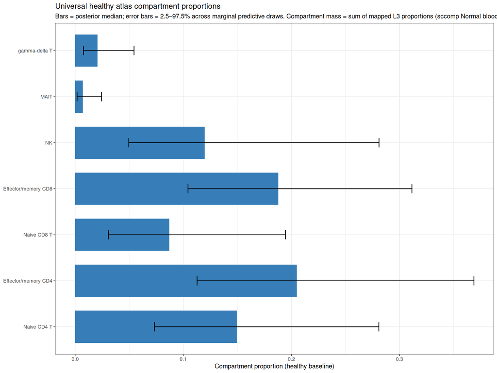

```r
healthy_baseline_compartment_universal <- predict_res |>
  dplyr::inner_join(
    paper_compartment_l3 |>
      dplyr::distinct(.data$paper_compartment, .data$cell_type),
    by = "cell_type"
  ) |>
  dplyr::group_by(.data$paper_compartment, .data$.draw) |>
  dplyr::summarise(
    compartment_proportion = sum(.data$proportion),
    .groups = "drop"
  ) |>
  dplyr::group_by(.data$paper_compartment) |>
  dplyr::summarise(
    median_proportion = stats::median(.data$compartment_proportion),
    hpd_lo = stats::quantile(.data$compartment_proportion, 0.025),
    hpd_hi = stats::quantile(.data$compartment_proportion, 0.975),
    .groups = "drop"
  ) |>
  dplyr::mutate(
    paper_compartment = factor(
      .data$paper_compartment,
      levels = paper_compartment_levels
    )
  )

ggplot2::ggplot(
  healthy_baseline_compartment_universal,
  ggplot2::aes(
    x = paper_compartment,
    y = median_proportion
  )
) +
  ggplot2::geom_col(fill = "#377EB8", width = 0.7) +
  ggplot2::geom_errorbar(
    ggplot2::aes(ymin = hpd_lo, ymax = hpd_hi),
    width = 0.2,
    linewidth = 0.6
  ) +
  ggplot2::coord_flip() +
  ggplot2::labs(
    title = "Universal healthy atlas compartment proportions",
    subtitle = paste(
      "Bars = posterior median; error bars = 2.5–97.5% across marginal predictive draws.",
      "Compartment mass = sum of mapped L3 proportions (sccomp Normal blood; NA sex/age/dataset/assay/ethnicity)."
    ),
    x = NULL,
    y = "Compartment proportion (healthy baseline)"
  ) +
  ggplot2::theme_bw()
```

### Observed composition (within cohort)

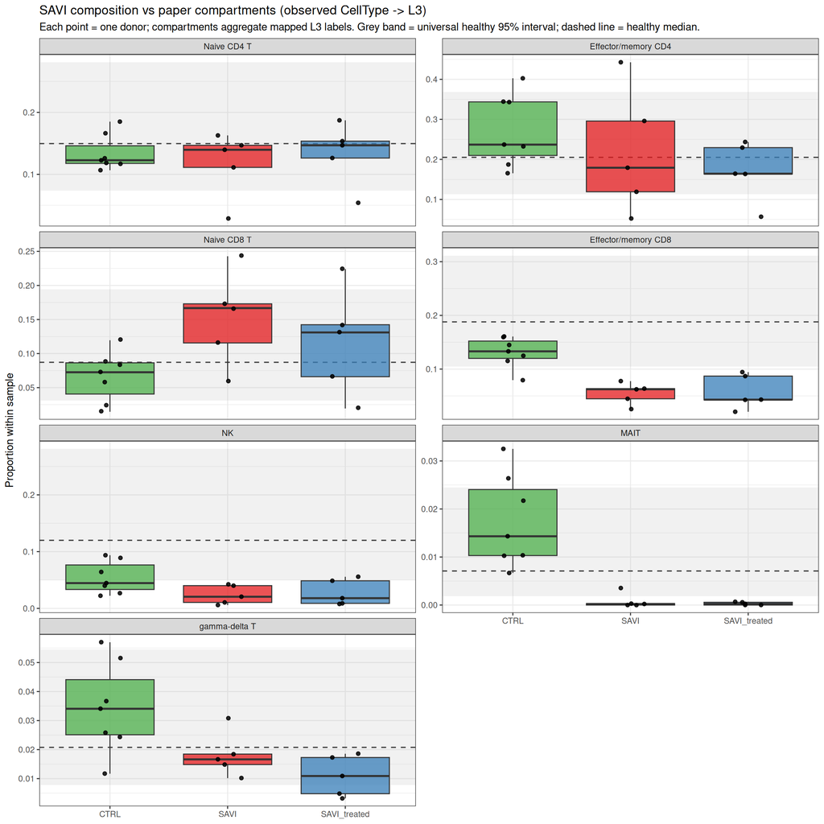

```r
category_cols <- c(
  CTRL = "#4DAF4A",
  SAVI = "#E41A1C",
  SAVI_treated = "#377EB8"
)

plot_data <- composition_paper_long |>
  dplyr::mutate(
    Category = factor(.data$Category, levels = names(category_cols)),
    paper_compartment = factor(.data$paper_compartment, levels = paper_compartment_levels)
  )

healthy_baseline_compartment_plot <- healthy_baseline_compartment_universal |>
  dplyr::mutate(
    paper_compartment = factor(
      .data$paper_compartment,
      levels = levels(plot_data$paper_compartment)
    )
  )

ggplot2::ggplot(
  plot_data,
  ggplot2::aes(
    x = Category,
    y = proportion_observed,
    fill = Category
  )
) +
  ggplot2::geom_rect(
    data = healthy_baseline_compartment_plot,
    ggplot2::aes(
      xmin = -Inf,
      xmax = Inf,
      ymin = .data$hpd_lo,
      ymax = .data$hpd_hi
    ),
    fill = "grey70",
    alpha = 0.18,
    inherit.aes = FALSE
  ) +
  ggplot2::geom_hline(
    data = healthy_baseline_compartment_plot,
    ggplot2::aes(yintercept = .data$median_proportion),
    colour = "grey25",
    linewidth = 0.6,
    linetype = "dashed",
    inherit.aes = FALSE
  ) +
  ggplot2::geom_boxplot(outlier.shape = NA, alpha = 0.75) +
  ggplot2::geom_jitter(width = 0.12, size = 1.6, alpha = 0.85) +
  ggplot2::facet_wrap(~paper_compartment, scales = "free_y", ncol = 2) +
  ggplot2::scale_fill_manual(values = category_cols) +
  ggplot2::labs(
    title = "SAVI composition vs paper compartments (observed CellType -> L3)",
    subtitle = paste(
      "Each point = one donor; compartments aggregate mapped L3 labels.",
      "Grey band = universal healthy 95% interval; dashed line = healthy median."
    ),
    x = NULL,
    y = "Proportion within sample"
  ) +
  ggplot2::theme_bw() +
  ggplot2::theme(legend.position = "none")
```

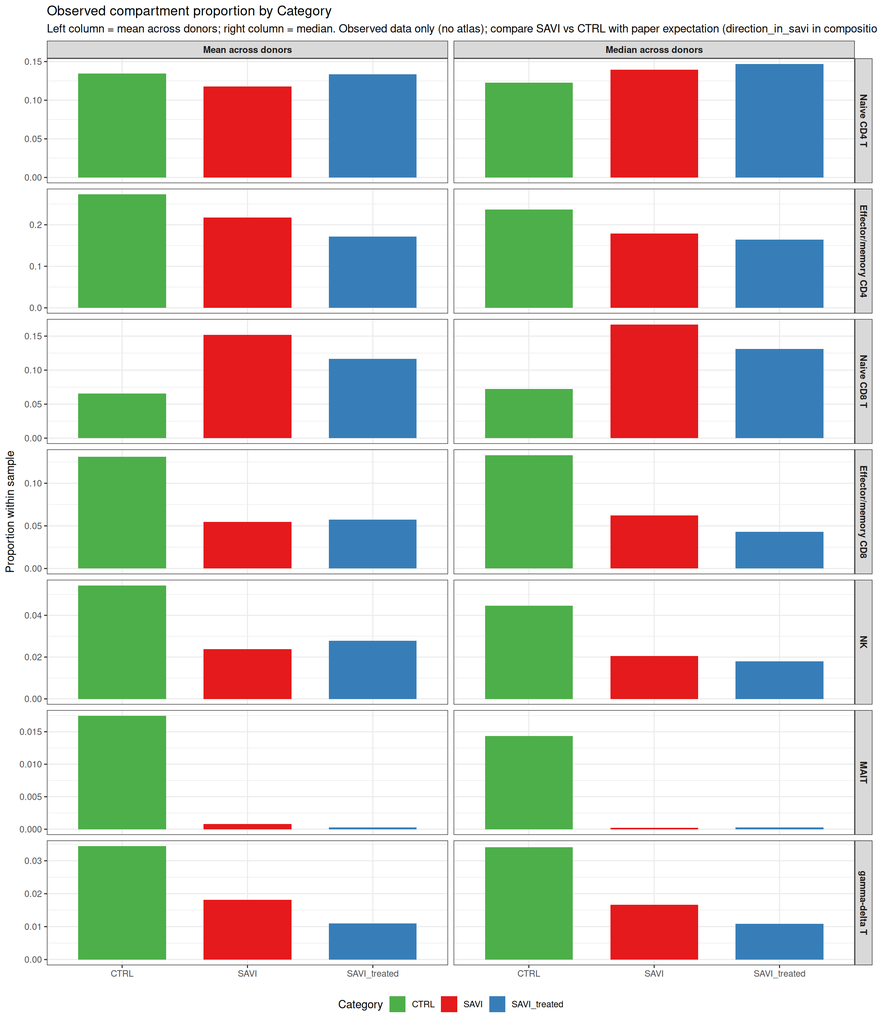

```r
composition_paper_bar <- composition_paper_summary |>
  tidyr::pivot_longer(
    cols = c(
      tidyselect::starts_with("mean_prop__"),
      tidyselect::starts_with("median_prop__")
    ),
    names_to = c("statistic", "Category"),
    names_sep = "__",
    values_to = "prop"
  ) |>
  dplyr::mutate(
    statistic = dplyr::recode(
      .data$statistic,
      mean_prop = "Mean across donors",
      median_prop = "Median across donors"
    ),
    statistic = factor(
      .data$statistic,
      levels = c("Mean across donors", "Median across donors")
    ),
    Category = factor(.data$Category, levels = names(category_cols)),
    paper_compartment = factor(.data$paper_compartment, levels = paper_compartment_levels)
  )

ggplot2::ggplot(
  composition_paper_bar,
  ggplot2::aes(x = Category, y = prop, fill = Category)
) +
  ggplot2::geom_col(position = ggplot2::position_dodge(width = 0.8), width = 0.7) +
  ggplot2::facet_grid(
    paper_compartment ~ statistic,
    scales = "free_y"
  ) +
  ggplot2::scale_fill_manual(values = category_cols) +
  ggplot2::labs(
    title = "Observed compartment proportion by Category",
    subtitle = paste(
      "Left column = mean across donors; right column = median.",
      "Observed data only (no atlas); compare SAVI vs CTRL with paper expectation",
      "(direction_in_savi in composition_paper_summary)."
    ),
    x = NULL,
    y = "Proportion within sample"
  ) +
  ggplot2::theme_bw() +
  ggplot2::theme(
    legend.position = "bottom",
    strip.text = ggplot2::element_text(size = 9, face = "bold")
  )
```

### SAVI donors vs healthy baseline (unified compartments)

For **`SAVI`** and **`SAVI_treated`** donors only, we compare each donor’s **compartment proportion** (sum of mapped L3 types) to the **universal (pooled)** healthy **`predict_res`** draws. We then ask whether the atlas tail call (`higher` / `lower` / `consistent` vs healthy) agrees with the **paper’s expected direction** in SAVI (increased vs decreased).

```r
baseline_compartment_draws <- predict_res |>
  dplyr::inner_join(
    paper_compartment_l3 |>
      dplyr::distinct(.data$paper_compartment, .data$cell_type),
    by = "cell_type"
  ) |>
  dplyr::group_by(.data$paper_compartment, .data$.draw) |>
  dplyr::summarise(
    compartment_proportion = sum(.data$proportion),
    .groups = "drop"
  )

donor_metadata_display <- example_proportions |>
  dplyr::distinct(.data$sample_id, .data$sex, .data$age_decade) |>
  dplyr::rename(sample_id_observed = sample_id)

# One reference table for all donors: tail test vs universal (pooled) healthy draws.
composition_universal_reference <- composition_paper_long |>
  dplyr::left_join(donor_metadata_display, by = "sample_id_observed") |>
  dplyr::inner_join(
    baseline_compartment_draws,
    by = "paper_compartment",
    relationship = "many-to-many"
  ) |>
  dplyr::group_by(
    .data$sample_id_observed,
    .data$Category,
    .data$sex,
    .data$age_decade,
    .data$paper_compartment,
    .data$direction_in_savi,
    .data$proportion_observed
  ) |>
  dplyr::summarise(
    healthy_median = stats::median(.data$compartment_proportion),
    healthy_hpd_lo = stats::quantile(.data$compartment_proportion, 0.025),
    healthy_hpd_hi = stats::quantile(.data$compartment_proportion, 0.975),
    p_above_healthy = mean(.data$compartment_proportion >= .data$proportion_observed),
    p_below_healthy = mean(.data$compartment_proportion <= .data$proportion_observed),
    empirical_confidence = 2 * pmin(.data$p_above_healthy, .data$p_below_healthy),
    direction_vs_healthy = dplyr::case_when(
      .data$p_above_healthy < 0.025 ~ "higher_than_healthy",
      .data$p_below_healthy < 0.025 ~ "lower_than_healthy",
      TRUE ~ "consistent_with_healthy"
    ),
    .groups = "drop"
  )

composition_savi_vs_healthy <- composition_universal_reference |>
  dplyr::filter(.data$Category %in% c("SAVI", "SAVI_treated")) |>
  dplyr::mutate(
    atlas_direction_simple = dplyr::case_when(
      .data$direction_vs_healthy == "higher_than_healthy" ~ "increased",
      .data$direction_vs_healthy == "lower_than_healthy" ~ "decreased",
      TRUE ~ "consistent"
    ),
    agrees_with_paper = dplyr::case_when(
      .data$direction_in_savi == "increased" ~
        .data$atlas_direction_simple == "increased",
      .data$direction_in_savi %in% c("decreased", "strongly decreased") ~
        .data$atlas_direction_simple == "decreased",
      TRUE ~ NA
    ),
    agreement_label = dplyr::case_when(
      .data$agrees_with_paper %in% TRUE ~ "agrees (atlas vs paper)",
      .data$agrees_with_paper %in% FALSE ~ "disagrees (atlas vs paper)",
      TRUE ~ "atlas consistent (no tail)"
    )
  )

composition_savi_vs_healthy |>
  dplyr::arrange(.data$Category, .data$paper_compartment, .data$sample_id_observed)
```

| sample_id_observed | Category | sex | age_decade | paper_compartment | direction_in_savi | proportion_observed | healthy_median | healthy_hpd_lo | healthy_hpd_hi | p_above_healthy | p_below_healthy | empirical_confidence | direction_vs_healthy | atlas_direction_simple | agrees_with_paper | agreement_label |
| --- | --- | --- | --- | --- | --- | --- | --- | --- | --- | --- | --- | --- | --- | --- | --- | --- |
| P1_STING_ht | SAVI | female | 1 | Effector/memory CD4 | decreased | 0.2958199357 | 0.205112688 | 0.112772482 | 0.36880792 | 0.132 | 0.868 | 0.264 | consistent_with_healthy | consistent | FALSE | disagrees (atlas vs paper) |
| P2_STING_ht | SAVI | male | 4 | Effector/memory CD4 | decreased | 0.4426195426 | 0.205112688 | 0.112772482 | 0.36880792 | 0.004 | 0.996 | 0.008 | higher_than_healthy | increased | FALSE | disagrees (atlas vs paper) |
| P4_STING_ht | SAVI | male | 1 | Effector/memory CD4 | decreased | 0.1791621580 | 0.205112688 | 0.112772482 | 0.36880792 | 0.664 | 0.336 | 0.672 | consistent_with_healthy | consistent | FALSE | disagrees (atlas vs paper) |
| P5_STING | SAVI | male | 1 | Effector/memory CD4 | decreased | 0.1191343964 | 0.205112688 | 0.112772482 | 0.36880792 | 0.962 | 0.038 | 0.076 | consistent_with_healthy | consistent | FALSE | disagrees (atlas vs paper) |
| P6_STING_ht | SAVI | male | 1 | Effector/memory CD4 | decreased | 0.0525285972 | 0.205112688 | 0.112772482 | 0.36880792 | 1.000 | 0.000 | 0.000 | lower_than_healthy | decreased | TRUE | agrees (atlas vs paper) |
| P1_STING_ht | SAVI | female | 1 | Effector/memory CD8 | decreased | 0.0634788922 | 0.187913433 | 0.104400322 | 0.31146722 | 0.998 | 0.002 | 0.004 | lower_than_healthy | decreased | TRUE | agrees (atlas vs paper) |
| P2_STING_ht | SAVI | male | 4 | Effector/memory CD8 | decreased | 0.0775467775 | 0.187913433 | 0.104400322 | 0.31146722 | 0.996 | 0.004 | 0.008 | lower_than_healthy | decreased | TRUE | agrees (atlas vs paper) |
| P4_STING_ht | SAVI | male | 1 | Effector/memory CD8 | decreased | 0.0446746019 | 0.187913433 | 0.104400322 | 0.31146722 | 1.000 | 0.000 | 0.000 | lower_than_healthy | decreased | TRUE | agrees (atlas vs paper) |
| P5_STING | SAVI | male | 1 | Effector/memory CD8 | decreased | 0.0624145786 | 0.187913433 | 0.104400322 | 0.31146722 | 1.000 | 0.000 | 0.000 | lower_than_healthy | decreased | TRUE | agrees (atlas vs paper) |
| P6_STING_ht | SAVI | male | 1 | Effector/memory CD8 | decreased | 0.0255869958 | 0.187913433 | 0.104400322 | 0.31146722 | 1.000 | 0.000 | 0.000 | lower_than_healthy | decreased | TRUE | agrees (atlas vs paper) |

[output cut: 60 more lines]

```r
composition_savi_agreement_summary <- composition_savi_vs_healthy |>
  dplyr::group_by(.data$Category, .data$paper_compartment, .data$direction_in_savi) |>
  dplyr::summarise(
    n_donors = dplyr::n(),
    n_higher = sum(.data$direction_vs_healthy == "higher_than_healthy"),
    n_lower = sum(.data$direction_vs_healthy == "lower_than_healthy"),
    n_consistent = sum(.data$direction_vs_healthy == "consistent_with_healthy"),
    n_agrees_paper = sum(.data$agrees_with_paper %in% TRUE, na.rm = TRUE),
    n_disagrees_paper = sum(.data$agrees_with_paper %in% FALSE, na.rm = TRUE),
    n_testable = sum(!is.na(.data$agrees_with_paper)),
    pct_agrees_paper = dplyr::if_else(
      sum(!is.na(.data$agrees_with_paper)) > 0L,
      100 * mean(.data$agrees_with_paper, na.rm = TRUE),
      NA_real_
    ),
    .groups = "drop"
  ) |>
  dplyr::arrange(.data$Category, .data$paper_compartment)

composition_savi_agreement_summary
```

| Category | paper_compartment | direction_in_savi | n_donors | n_higher | n_lower | n_consistent | n_agrees_paper | n_disagrees_paper | n_testable | pct_agrees_paper |
| --- | --- | --- | --- | --- | --- | --- | --- | --- | --- | --- |
| SAVI | Effector/memory CD4 | decreased | 5 | 1 | 1 | 3 | 1 | 4 | 5 | 20 |
| SAVI | Effector/memory CD8 | decreased | 5 | 0 | 5 | 0 | 5 | 0 | 5 | 100 |
| SAVI | MAIT | strongly decreased | 5 | 0 | 4 | 1 | 4 | 1 | 5 | 80 |
| SAVI | NK | decreased | 5 | 0 | 5 | 0 | 5 | 0 | 5 | 100 |
| SAVI | Naive CD4 T | increased | 5 | 0 | 1 | 4 | 0 | 5 | 5 | 0 |
| SAVI | Naive CD8 T | increased | 5 | 1 | 0 | 4 | 1 | 4 | 5 | 20 |
| SAVI | gamma-delta T | strongly decreased | 5 | 0 | 0 | 5 | 0 | 5 | 5 | 0 |
| SAVI_treated | Effector/memory CD4 | decreased | 5 | 0 | 1 | 4 | 1 | 4 | 5 | 20 |
| SAVI_treated | Effector/memory CD8 | decreased | 5 | 0 | 5 | 0 | 5 | 0 | 5 | 100 |
| SAVI_treated | MAIT | strongly decreased | 5 | 0 | 5 | 0 | 5 | 0 | 5 | 100 |

[output cut: 4 more lines]

```r
# Diagnostic: heatmap tail call vs observed relative to universal healthy median.
composition_naive_cd4_check <- composition_universal_reference |>
  dplyr::filter(
    .data$paper_compartment == "Naive CD4 T",
    .data$Category == "SAVI"
  ) |>
  dplyr::transmute(
    sample_id_observed,
    age_decade,
    sex,
    proportion_observed,
    healthy_median_matched = .data$healthy_median,
    delta_obs_minus_matched = .data$proportion_observed - .data$healthy_median,
    direction_vs_healthy,
    visual_check = dplyr::case_when(
      .data$direction_vs_healthy == "higher_than_healthy" ~
        "solid line should be RIGHT of dashed median",
      .data$direction_vs_healthy == "lower_than_healthy" ~
        "solid line should be LEFT of dashed median",
      TRUE ~ "solid line near dashed median"
    )
  )

composition_naive_cd4_check
```

| sample_id_observed | age_decade | sex | proportion_observed | healthy_median_matched | delta_obs_minus_matched | direction_vs_healthy | visual_check |
| --- | --- | --- | --- | --- | --- | --- | --- |
| P1_STING_ht | 1 | female | 0.14687273 | 0.1495638 | -0.002691099 | consistent_with_healthy | solid line near dashed median |
| P2_STING_ht | 4 | male | 0.16278586 | 0.1495638 | 0.013222033 | consistent_with_healthy | solid line near dashed median |
| P4_STING_ht | 1 | male | 0.13958881 | 0.1495638 | -0.009975022 | consistent_with_healthy | solid line near dashed median |
| P5_STING | 1 | male | 0.11116173 | 0.1495638 | -0.038402099 | consistent_with_healthy | solid line near dashed median |
| P6_STING_ht | 1 | male | 0.02874774 | 0.1495638 | -0.120816088 | lower_than_healthy | solid line should be LEFT of dashed median |